# STA553 HOMEWORK 2

Simon Qiao

2/24/2022

[figure not shown]

```r
p <- read.csv("https://raw.githubusercontent.com/simonqdy/sta553/main/data/w02-penguins.csv")
penguins <- mutate(p, body_mass = body_mass_g/3000)

library(png)
penguin_pic <- image_read("https://github.com/simonqdy/sta553/blob/main/image/penguin.png?raw=true")
#pp <- image_scale(penguin_pic,"50")

bill_length_mm = penguins$bill_length_mm
flipper_length_mm = penguins$flipper_length_mm
body_mass = penguins$body_mass
species = penguins$species
## identifying the ID
adelie.id = which(species=="Adelie")
gentoo.id = which(species=="Gentoo")
chinstrap.id = which(species=="Chinstrap")
## color code
col.code =  c(alpha("orange",0.3),alpha("blue",0.3),alpha("red",0.3))

plot(bill_length_mm, flipper_length_mm,
     xlab = "Bill Length (mm)",
     ylab = "Flipper Length (mm)",
     col.lab = "Blue",
     cex.lab = 1,
     font.lab = 3,
     type = "n")
title(main = "Flipper Length vs Bill Length",
     col.main = "Orange",
     font.main = 2,
     cex.main = 2,
     adj = 0)

## change the point size based on their boday_mass
points(bill_length_mm[adelie.id], flipper_length_mm[adelie.id],
       pch = 15, col = col.code[1], cex = body_mass[adelie.id])
points(bill_length_mm[gentoo.id], flipper_length_mm[gentoo.id],
       pch = 15, col = col.code[2], cex = body_mass[gentoo.id])
points(bill_length_mm[chinstrap.id], flipper_length_mm[chinstrap.id],
       pch = 15, col = col.code[3], cex = body_mass[chinstrap.id])
legend(32, 231, c("Adelie", "Gentoo", "Chinstrap"),
                  col=col.code,
                  pch=c(15, 15, 15))

rasterImage(penguin_pic,55,184,60,203)

text(50, 173, "The point size is proportional to body_mass_g", col = "navy", cex = 1)
```

```r
vars <- c("species", "island", "body_mass_g")
cond <- c("Chinstrap", "Dream", 3500, 5000)
penguins <- p %>%
na.omit() %>%
  filter(
    .data[[vars[1]]] != cond[[1]],
    .data[[vars[2]]] != cond[[2]],
    .data[[vars[3]]] > cond[[3]] & .data[[vars[3]]] < cond[[4]]
  ) %>%
mutate(BMI = body_mass_g/4000) %>%
select(-X, -sex, -year, -body_mass_g)

species.p <- group_by(penguins, species)
summarize(species.p, avg.bill_length_mm = mean(bill_length_mm), avg.flipper_length_mm = mean(flipper_length_mm))
```

```
## # A tibble: 2 × 3
##   species avg.bill_length_mm avg.flipper_length_mm
##   <chr>                <dbl>                 <dbl>
## 1 Adelie                39.7                  192.
## 2 Gentoo                45.6                  213.
```

```r
species.island <- group_by(penguins, species, island)
summarize(species.island, n.species.island = n())
```

```
## # A tibble: 3 × 3
## # Groups:   species [2]
##   species island    n.species.island
##   <chr>   <chr>                <int>
## 1 Adelie  Biscoe                  30
## 2 Adelie  Torgersen               29
## 3 Gentoo  Biscoe                  52
```

```r
summarize(species.island, avg.bill_length_mm = mean(bill_length_mm), avg.flipper_length_mm = mean(flipper_length_mm))
```

```
## # A tibble: 3 × 4
## # Groups:   species [2]
##   species island    avg.bill_length_mm avg.flipper_length_mm
##   <chr>   <chr>                  <dbl>                 <dbl>
## 1 Adelie  Biscoe                  39.7                  191.
## 2 Adelie  Torgersen               39.6                  193.
## 3 Gentoo  Biscoe                  45.6                  213.
```

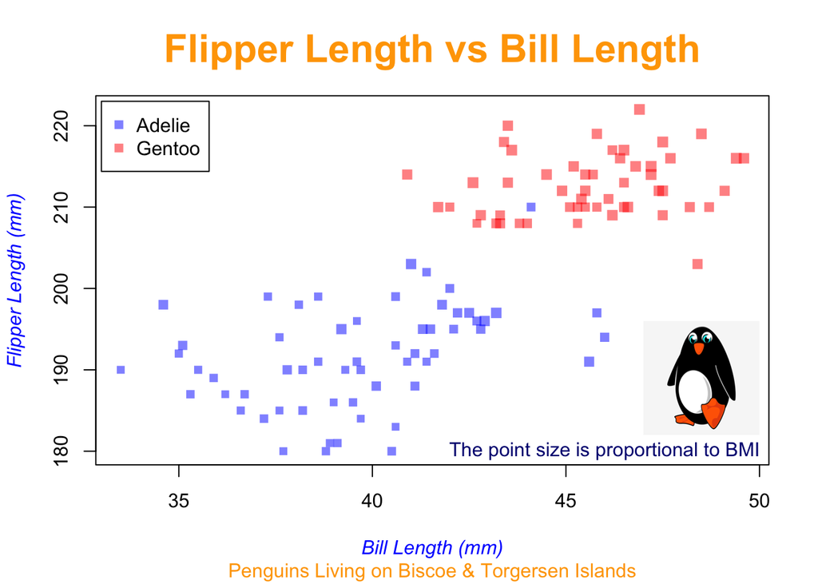

```r
bill_length_mm = penguins$bill_length_mm
flipper_length_mm = penguins$flipper_length_mm
BMI = penguins$BMI
species = penguins$species
island = penguins$island
## identifying the ID
adelie.id = which(species=="Adelie")
gentoo.id = which(species=="Gentoo")
## color code
col.code =  c(alpha("blue",0.5),alpha("red",0.5))
plot(bill_length_mm, flipper_length_mm,
     xlab = "Bill Length (mm)",
     ylab = "Flipper Length (mm)",
     col.lab = "Blue",
     cex.lab = 1,
     font.lab = 3,type = "n")
title(main = "Flipper Length vs Bill Length",
     col.main = "Orange",
     font.main = 2,
     cex.main = 2,
     adj.main = 0,
     sub = "Penguins Living on Biscoe & Torgersen Islands",
     col.sub = "Orange",
     cex.sub = 1,
     adj.sub = 1)
## change the point size based on their body_mass
points(bill_length_mm[adelie.id], flipper_length_mm[adelie.id],
       pch = 15, col = col.code[1], cex = BMI[adelie.id])
points(bill_length_mm[gentoo.id], flipper_length_mm[gentoo.id],
       pch = 15, col = col.code[2], cex = BMI[gentoo.id])

legend(33 ,223, c("Adelie", "Gentoo"),
                  col=col.code,
                  pch=c(15, 15))

rasterImage(penguin_pic,47,182,50,196)

text(46, 180, "The point size is proportional to BMI", col = "navy", cex = 1)
```

There’re 111 penguins selected in this research, out of which 29 Adelie penguins live on Torgersen Island, 30 Adelie penguins and 52 Gentoo penguins live on Biscoe Island only. Adelie penguins are overall smaller than Gentoo penguins regardless the location of their habitats. The average bill length of Adelie penguins is 39.68mm, and the average flipper length of Adelie penguins is 191.66mm, while the average bill length and average flipper length of Gentoo penguins are 45.62mm(15% longer than Adilie) and 212.58mm(11% longer than Adelie). Within Adelie penguins, the average bill length of the ones from Biscoe Island is 39.74mm and that of Torgersen Island is 39.62mm. The average flipper length of Adelie penguins from Biscoe Island is 190.53mm and that of Torgersen Island is 192.83mm, which is only 1.2% longer. The location of the habitats doesn’t seem to impact the measures of Adelie penguins.